```python
import numpy as np
import numpy.matlib
import matplotlib.pyplot as plt
from matplotlib.colors import ListedColormap
from scipy.spatial.distance import cdist
from skimage import io, img_as_ubyte, img_as_float64
from sklearn.metrics import silhouette_score

from load_mnist import load_mnist
from sklearn.cluster import SpectralClustering
from sklearn.cluster import KMeans
from sklearn.mixture import GaussianMixture
from sklearn.metrics import rand_score
from sklearn.manifold import SpectralEmbedding

%matplotlib inline
```

# Exploring Clustering Methods

## Old Faithful Dataset

We begin by loading the Old Faithful dataset. The data includes the waiting time between eruptions and the duration of the eruption for the Old Faithful geyser in Yellowstone National Park, Wyoming, USA. The data can be described as follows:

```
 A data frame with 272 observations on 2 variables.

eruptions  numeric  Eruption time in mins
waiting    numeric  Waiting time to next eruption
```

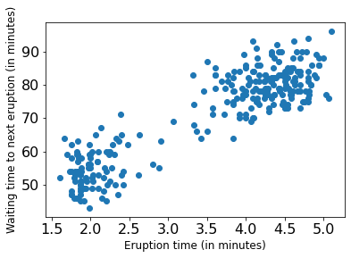

```python
old_faithful_dataset = np.loadtxt("faithful.csv", delimiter=" ", skiprows=0)
plt.scatter(old_faithful_dataset[:, 0], old_faithful_dataset[:, 1])
plt.xlabel('Eruption time (in minutes)', fontsize=12)
plt.ylabel('Waiting time to next eruption (in minutes)', fontsize=12)
plt.xticks(fontsize=16)
plt.yticks(fontsize=16);
```

## K-means clustering

We write a function **k_means_clustering** that performs $k$-means clustering for the input **data** and a number of clusters **no_of_clusters**.

Here **data** is matrix $X = \left( \begin{matrix} x_1^\top \\ \vdots \\ x_s^\top \end{matrix} \right) \in \mathbb{R}^{s \times d}$ of $s$ $d$-dimensional vectors.  
Optional arguments are:

1. Initialisation for the centroids (**init_centroids**).
2. Maximum number of iterations (**maximum_counter**).
3. Tolerance parameter for when the iteration is considered to have converged (**tolerance**) .
4. A parameter that determines after how many iterations a progress-update is printed (**print_output**).

If **init_centroids** is set to **None**, then we initialise it as a 2D array of normally distributed random variables with mean zero and standard deviation one.  
The algorithm stops as soon as $\left(L(z^k, \mu^k) - L(z^{k + 1}, \mu^{k + 1})\right) / L(z^{k + 1}, \mu^{k + 1}) \leq \text{tolerance}$. $L$ denotes the k-means clustering objective

$$ L(z, \mu) = \sum_{i = 1}^s \sum_{j = 1}^k z_{ij} \| x_i - \mu_j \|^2 \, . $$

The function returns the following:

- **centroids** = a matrix $\mu = \left( \begin{matrix} \mu_1^\top \\ \vdots \\ \mu_k^\top \end{matrix} \right) \in \mathbb{R}^{k \times d}$ that contains all $k$ centroid vectors.
- **assignments** = a matrix $z \in \{0, 1\}^{s \times k}$ that contains the cluster assignments for each sample.

```python
def k_means_clustering(data, no_of_clusters, init_centroids=None, maximum_counter=300, tolerance=1e-9, \
                       print_output=10):

    no_of_samples, dimension = data.shape

    if init_centroids is None:
        centroids = np.zeros((no_of_clusters, dimension))
        centroids = np.random.normal(size=(no_of_clusters, dimension))
    else:
        centroids = init_centroids

    print(f'centroids_init: \n {centroids}')

    distances = cdist(data, centroids, 'euclidean')
    assignments = np.zeros((no_of_samples, no_of_clusters))
    for idx in range(no_of_samples):
        assignments[idx, np.argmin(distances[idx])] = 1

    for _ in range(maximum_counter):

        old_centroids = centroids
        old_assignments = assignments

        for k in range(no_of_clusters):
            centroids[k] = data[assignments[:,k]==1].mean(axis=0)
        distances = cdist(data, centroids ,'euclidean')

        assignments = np.zeros((no_of_samples, no_of_clusters))
        for idx in range(no_of_samples):
            assignments[idx, np.argmin(distances[idx])] = 1

        old_loss = 0
        new_loss = 0
        for i in range(no_of_samples):
            for k in range(no_of_clusters):
                old_loss += old_assignments[i,k] * np.linalg.norm(data[i] - old_centroids[k])**2
                new_loss += assignments[i,k] * np.linalg.norm(data[i] - centroids[k])**2

        loss_ratio = (old_loss - new_loss) / new_loss

        if (_+1)%print_output==0:
            print(f'Iteration {_+1}, Loss: {new_loss}')
            print(f'Centroids: \n {centroids}')

        if loss_ratio < tolerance:
            print(f'Finished after {_+1} iterations.')
            break

    return centroids, assignments
```

We cluster the Old Faithful dataset into two clusters, initialising our centroids with the two centroid vectors $\mu_1 = \left( \begin{matrix} 3.5 & 50\end{matrix}\right)^\top$ and $\mu_2 = \left( \begin{matrix} 3 & 80\end{matrix}\right)^\top$.

```python
centroids, assignments = k_means_clustering(old_faithful_dataset, no_of_clusters=2,
                                            init_centroids=np.array([[3.5, 50], [3, 80]]).reshape(2, 2), maximum_counter=300, tolerance=1e-9,
                                            print_output=10)
```

```
centroids_init:
 [[ 3.5 50. ]
 [ 3.  80. ]]
Finished after 2 iterations.
```

We plot the resulting clusters.

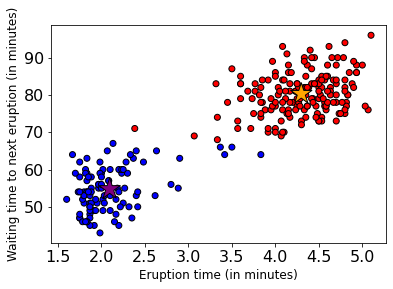

```python
colormap_bright = ListedColormap(['#FF0000', '#0000FF'])
plt.scatter(old_faithful_dataset[:, 0], old_faithful_dataset[:, 1], c=assignments[:, 0], cmap=colormap_bright, edgecolors='k')
plt.scatter(centroids[:, 0], centroids[:, 1], marker="*", s=500, color=["purple", "orange"], edgecolors='k')
plt.xlabel('Eruption time (in minutes)', fontsize=12)
plt.ylabel('Waiting time to next eruption (in minutes)', fontsize=12)
plt.xticks(fontsize=16)
plt.yticks(fontsize=16)
plt.tight_layout;
```

```python
labels = [np.argmax(i) for i in assignments]
SC = silhouette_score(old_faithful_dataset, labels)

print('The silhouette score is: %f' % SC)
```

```
The silhouette score is: 0.724055
```

This is a fairly good result.

## MNIST Dataset

We define a function to import the required dataset.

```python
def load_mnist(path, kind = 'train'):

    import os
    import gzip
    import numpy as np

    """Load MNIST data from `path`"""
    labels_path = os.path.join(path,
                               '%s-labels-idx1-ubyte.gz'
                               % kind)
    images_path = os.path.join(path,
                               '%s-images-idx3-ubyte.gz'
                               % kind)

    with gzip.open(labels_path, 'rb') as lbpath:
        labels = np.frombuffer(lbpath.read(), dtype=np.uint8,
                               offset=8)

    with gzip.open(images_path, 'rb') as imgpath:
        images = np.frombuffer(imgpath.read(), dtype=np.uint8,
                               offset=16).reshape(len(labels), 784)

    return images, labels
```

```python
mnist_im, mnist_lb = load_mnist('DigitMNIST/')
```

The MNIST dataset is a collection of grayscale images of handwritten digits (0,1,...,9).  
Here, for simplicity, we will only look at the images representing the digits **4,6,8**, and to make the algorithms run faster we take the first 1000 images.

```python
DIGITS = [4,6,8]

mnist_im_sub = mnist_im[(mnist_lb==4) | (mnist_lb==6) | (mnist_lb==8)]
mnist_lb_sub = mnist_lb[(mnist_lb==4) | (mnist_lb==6) | (mnist_lb==8)]

mnist_im_sub = mnist_im_sub[:1000]
mnist_lb_sub = mnist_lb_sub[:1000]
```

Here is a sample of these images.

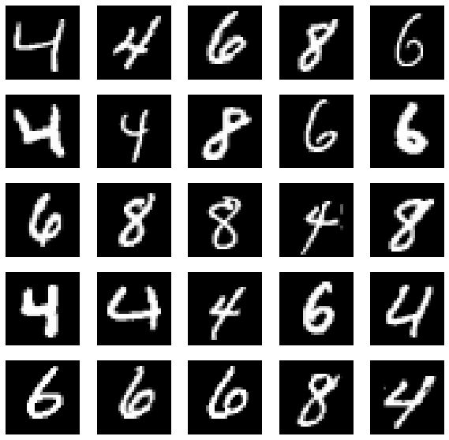

```python
M = 5
plt.figure(figsize=(10,10))
for i in range(M):
    for j in range(M):
        t = j+i*M
        plt.subplot(M,M,t+1)
        plt.imshow(np.reshape(mnist_im_sub[t, :], (28, 28)), cmap='gray')
        plt.axis('off')
```

We use the **KMeans**, **GaussianMixture** and **SpectralClustering** methods from **SKlearn** and compare them.

```python
km_model = KMeans(n_clusters=3).fit(mnist_im_sub)
km_labels = km_model.labels_
km_centers = km_model.cluster_centers_
```

```python
gmm_model = GaussianMixture(n_components=3).fit(mnist_im_sub)
gm_labels = gmm_model.predict(mnist_im_sub)
gm_centers = gmm_model.means_
```

```python
sc_model = SpectralClustering(n_clusters=3, affinity='nearest_neighbors').fit(mnist_im_sub)
sp_labels = sc_model.labels_
```

```
KMeans: [1 1 0 2 0 1 1 2 0 0]
GMM:    [1 1 2 0 2 1 1 0 2 2]
SC:     [1 1 2 0 2 1 1 0 2 2]
```

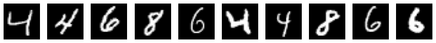

```python
M = 10
plt.figure(figsize=(15,5))
for i in range(M):
    plt.subplot(1,M,i+1)
    plt.imshow(np.reshape(mnist_im_sub[i, :], (28, 28)), cmap='gray')
    plt.axis('off')

print(f'KMeans: {km_labels[:10]}')
print(f'GMM:    {gm_labels[:10]}')
print(f'SC:     {sp_labels[:10]}')
```

All methods have clustered the images perfectly.

As a second check, we display the centers of the clusters for **KMeans** and **GMM** (the nature of **SpectralEmbedding** means it does not have centroid vectors).

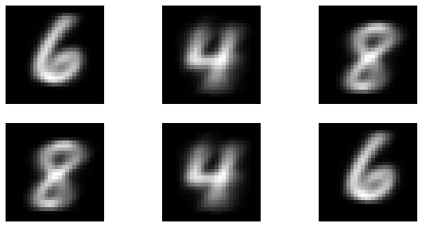

```python
plt.figure(figsize=(10, 5))
K=3
for counter in range(K):
    im_show_km = km_centers[counter].reshape(28,28)
    im_show_gm = gm_centers[counter].reshape(28,28)
    plt.subplot(2, K, counter+1)
    plt.imshow(im_show_km,cmap='gray')
    plt.axis('off')
    plt.subplot(2, K, counter+K+1)
    plt.imshow(im_show_gm,cmap='gray')
    plt.axis('off')
plt.tight_layout;
```

For spectral clustering, we want to examine the embedding that the algorithm produces.  
For that we can use **sklearn.manifold.SpectralEmbedding**.  
We apply the embedding $P:\mathbb{R}^{784}\to \mathbb{R}^2$ to transform the array of high dimensional vectors in **mnist_im_sub** ($1000\times 784$) into a new array **mnist_im_emb** that is of dimension $1000\times 2$.

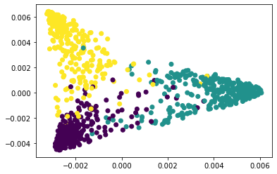

```python
embedding = SpectralEmbedding(n_components=2)
mnist_im_emb = embedding.fit_transform(mnist_im_sub)


plt.scatter(mnist_im_emb[:,0], mnist_im_emb[:,1], c=mnist_lb_sub);
```

Finally, we would like to get a quantitave estimate for the clustering quality of each of the methods.  
Since in this example we know what the ground truth is (the labels given by the MNIST database), we can use an external evaluation.  
We use **rand_score** (imported from sklearn.metrics) to compute the Rand Score for each of the three algorithms.

```python
km_RI = rand_score(mnist_lb_sub, km_labels)
gm_RI = rand_score(mnist_lb_sub, gm_labels)
sp_RI = rand_score(mnist_lb_sub, sp_labels)

print("Rand Index for K-Means clustering:         %.10f" % km_RI)
print("Rand Index for Gassian Mixture clustering: %.10f" % gm_RI)
print("Rand Index for Spectral clustering:        %.10f" % sp_RI)
```

```
Rand Index for K-Means clustering:         0.8779839840
Rand Index for Gassian Mixture clustering: 0.8802842843
Rand Index for Spectral clustering:        0.9549449449
```

Spectral Clustering appears to be the most effective.

## Image Compression

We explore another clustering application: compressing colour images.  
An 8-bit RGB image uses $256 = 2^8$ possible values per colour-channel. In other words, each pixel in the image requires $3\times 8 = 24$ bits of storage.  
Suppose we would like to approximate such an image with an $n$-bit RGB image, where $n < 24$. How do we choose the $3 n$ colour-intensity values, so that the image looks similar to the original image? This can be done with clustering methods.

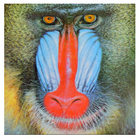

```python
image = img_as_float64(io.imread('mandrill.png'))
plt.imshow(image)
plt.axis('off')
plt.tight_layout;
```

We use the sklearn.cluster **KMeans** to apply the K-means clustering algorithm to the image.  
The number of clusters is set to be $2^\text{nbits}$, where **nbits** is number of bits used to store each pixel.  
We repeat the process for $\text{nbits} = 1,2,6$. Each image is a matrix of 480x480 RGB values, which we have to turn into a vector of 230,400 values.

```python
def compression(nbits):
    kmeans = KMeans(2**nbits).fit(image.reshape(image.shape[0] * image.shape[1], 3))
    centers = kmeans.cluster_centers_
    labels = kmeans.labels_
    return centers, labels

centers_1, labels_1 = compression(1)
print('done')

centers_2, labels_2 = compression(2)
print('done')

centers_6, labels_6 = compression(6)
print('done')
```

```
done
done
done
```

```python
image_comp_1 = centers_1[labels_1].reshape(480, 480, 3)
image_comp_2 = centers_2[labels_2].reshape(480, 480, 3)
image_comp_6 = centers_6[labels_6].reshape(480, 480, 3)
```

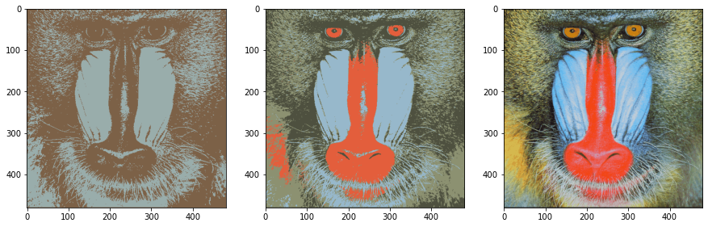

```python
fig, axs = plt.subplots(1, 3, figsize=(15,5))
axs = axs.ravel()
axs[0].imshow(image_comp_1)
axs[1].imshow(image_comp_2)
axs[2].imshow(image_comp_6)
```

Our results are pretty good.